# Dyngo-4a Treatment Split Retina

2024-01-09

# Introduction

In Melanoma-Associated Retinopathy (MAR), retinal rod bipolar cells internalize anti-TRPM1 autoantibodies, bringing them into their cytosol using an unknown mechanism. This experiment serves to elucidate the cellular mechanisms contributing to antibody uptake by pharmacologically inhibiting various endocytic pathways and observing the consequences on antibody uptake as seen in an *ex vivo* split mouse retina.

In this project, the effect of inhibiting dynamin-dependent endocytosis is observed by treating split retinas with Dyngo-4a. Briefly, the photoreceptors were removed from freshly isolated mouse retinas which were then incubated with an antibody for 1hr in the presence or absence of Dyngo 4a. The retinas were washed, then incubated with a viability dye to track cell death. Afterward, retinas were fixed, and the localization of the internalized antibodies was revealed by incubating the tissue with a labeled secondary antibody that targets the internalized antibody.

Microscopy data were collected on a Leica SPX8 Confocal microscope. Images were processed in Arivis software using a custom pipeline that quantifies internalized antibody only within rod bipolar cells (segmented based on transgenic Td tomato expression), excluding any dead cells or bright staining artefacts.

Channel guide:

- Channel 1 = Zombie dye
- Channel 2 = Td tomato
- Channel 3 = AF-488 (uptake)
- Channel 4 = DIC

# Data Import and Tidying

## Read in the Data

For each individual experiment, there is a separate excel workbook of data generated for every image. These are workbooks are placed into subfolders of the *data* directory. All workbooks from an experiment are imported into a list, then merged into a single data frame with `bind_rows`

Variable names are then cleaned with `janitor` and extraneous columns are excluded (can be retrieved for different analysis later)

The `read_n_clean` function also implements the `condition_select` method, which allows the user to assign treatment conditions (i.e DMSO vs Dyngo-4a) to samples by the name of the sample (i.e “s1.2)

```r
#e1-449
DMSO_imgs <- c("s1.2-1", "s1.2-2", "s2.1","s2.3")
dyngo_imgs <- c("s3.1", "s3.2", "s3.3", "s4.1", "s4.3")
e449 <- read_n_clean(folder_path = "data/e1-449", cond1_vec = DMSO_imgs, cond2_vec = dyngo_imgs, cond1_title = "DMSO", cond2_title = "Dyngo-4a")



#place all experiment dataframes into a list for batch processing
all_dyngo_exps <- list("e449" = e449)
```

# Data Analysis

The “mean_intensities_3” in the dataframe is an average of the signal intensity from channel 3 within a given RBC (segmented by its Td tomato reporter), so this is an individual cell average. We next need to average the signal across all cells on a given piece of tissue. There may be multiple (non-overlapping) images from a given piece of tissue, denoted by the number following the hyphen in the sample name:

s1.2**-1**

Begin by identifying all images that come from the same piece of tissue, using a Regex to identify this based on the sample name

```r
#regex string that will extract everything between the 's' and the '-' in the sample name
sample_string <- "s.*?.?(?=-)"

#add new variable "tissue" that uses the regex to match all images from the same piece of tissue
all_dyngo_exps <- lapply(all_dyngo_exps, function(x){mutate(x, tissue = str_extract(x$image_set, pattern = sample_string),.after = 1)})
all_dyngo_exps[1]
```

```
## $e449
## # A tibble: 43,431 × 9
##    image_set tissue    id min_intensities_3 max_intensities_3 mean_intensities_3
##    <chr>     <chr>  <dbl>             <dbl>             <dbl>              <dbl>
##  1 s1.2-1 -… s1.2       1                17                53              36.6
##  2 s1.2-1 -… s1.2       2                 0               169              58.6
##  3 s1.2-1 -… s1.2       3                 0                94              14.3
##  4 s1.2-1 -… s1.2       4                 0               157              19.9
##  5 s1.2-1 -… s1.2       5                 2                27               9.73
##  6 s1.2-1 -… s1.2       6                38                71              51.2
##  7 s1.2-1 -… s1.2       7                10               109              54.0
##  8 s1.2-1 -… s1.2       8                20                33              26
##  9 s1.2-1 -… s1.2       9                 2                61              22.5
## 10 s1.2-1 -… s1.2      10                43                84              67.8
## # ℹ 43,421 more rows
## # ℹ 3 more variables: sum_intensities_3 <dbl>, volume_volume_um3 <dbl>,
## #   condition <chr>
```

Next, group by `tissue` and average `mean_intensities_3`. Also group by `image_set` and average `mean_intensities_3`

```r
all_dyngo_exps <- lapply(all_dyngo_exps, function(x){
  x %>%
    group_by(tissue) %>% #first compute avg grouping by tissue (contains multiple images)
    mutate(tissue_avg = mean(mean_intensities_3)) %>%
    ungroup() %>%
    group_by(image_set) %>%
    mutate(img_avg = mean(mean_intensities_3)) %>%
    ungroup()
  })

all_dyngo_exps[1]
```

```
## $e449
## # A tibble: 43,431 × 11
##    image_set tissue    id min_intensities_3 max_intensities_3 mean_intensities_3
##    <chr>     <chr>  <dbl>             <dbl>             <dbl>              <dbl>
##  1 s1.2-1 -… s1.2       1                17                53              36.6
##  2 s1.2-1 -… s1.2       2                 0               169              58.6
##  3 s1.2-1 -… s1.2       3                 0                94              14.3
##  4 s1.2-1 -… s1.2       4                 0               157              19.9
##  5 s1.2-1 -… s1.2       5                 2                27               9.73
##  6 s1.2-1 -… s1.2       6                38                71              51.2
##  7 s1.2-1 -… s1.2       7                10               109              54.0
##  8 s1.2-1 -… s1.2       8                20                33              26
##  9 s1.2-1 -… s1.2       9                 2                61              22.5
## 10 s1.2-1 -… s1.2      10                43                84              67.8
## # ℹ 43,421 more rows
## # ℹ 5 more variables: sum_intensities_3 <dbl>, volume_volume_um3 <dbl>,
## #   condition <chr>, tissue_avg <dbl>, img_avg <dbl>
```

Checking to see that each image has a distinct average and each tissue has a distinct average. Looks good

```r
all_dyngo_exps[[1]] %>%
    group_by(image_set, tissue, condition, tissue_avg, img_avg) %>%
    summarise() %>%
  kbl() %>%
  kable_paper()
```

```
## 'tissue_avg'. You can override using the `.groups` argument.
```

| image_set | tissue | condition | tissue_avg | img_avg |
| --- | --- | --- | --- | --- |
| s1.2-1 - 24-01-04_e1-449.lif | s1.2 | DMSO | 22.999589 | 24.543512 |
| s1.2-2 - 24-01-04_e1-449.lif | s1.2 | DMSO | 22.999589 | 21.644832 |
| s2.1-1 - 24-01-04_e1-449.lif | s2.1 | DMSO | 12.388290 | 14.188436 |
| s2.1-2 - 24-01-04_e1-449.lif | s2.1 | DMSO | 12.388290 | 11.946912 |
| s2.1-3 - 24-01-04_e1-449.lif | s2.1 | DMSO | 12.388290 | 11.446001 |
| s2.3-1 - 24-01-04_e1-449.lif | s2.3 | DMSO | 19.766463 | 22.179733 |
| s2.3-2 - 24-01-04_e1-449.lif | s2.3 | DMSO | 19.766463 | 15.619854 |
| s2.3-3 - 24-01-04_e1-449.lif | s2.3 | DMSO | 19.766463 | 21.053184 |
| s3.1-1 - 24-01-04_e1-449.lif | s3.1 | Dyngo-4a | 10.796305 | 10.796305 |
| s3.2-1 - 24-01-04_e1-449.lif | s3.2 | Dyngo-4a | 10.793589 | 10.793589 |
| s4.1-1 - 24-01-04_e1-449.lif | s4.1 | Dyngo-4a | 8.048417 | 7.186370 |
| s4.1-2 - 24-01-04_e1-449.lif | s4.1 | Dyngo-4a | 8.048417 | 10.083057 |
| s4.1-3 - 24-01-04_e1-449.lif | s4.1 | Dyngo-4a | 8.048417 | 6.854345 |
| s4.3-1 - 24-01-04_e1-449.lif | s4.3 | Dyngo-4a | 7.998082 | 8.843711 |
| s4.3-2 - 24-01-04_e1-449.lif | s4.3 | Dyngo-4a | 7.998082 | 7.184621 |

Merge all dataframes in list into one dataframe

```r
all_dyngo_exps <- bind_rows(all_dyngo_exps, .id = "exp") %>%
  mutate(exp = as.factor(exp))
```

When plotting, each piece of tissue (tissue average) will be a point. The bar will be the *condition average* and will be made after merging all experiments into a single dataframe.

```r
all_dyngo_exps <- all_dyngo_exps %>%
    group_by(condition) %>%
    mutate(condition_avg = mean(tissue_avg),
           condition_sd = sd(tissue_avg)) %>%
    ungroup()

#all_dyngo_exps
```

# Plotting

```
## 'tissue_avg', 'condition_sd'. You can override using the `.groups` argument.
```

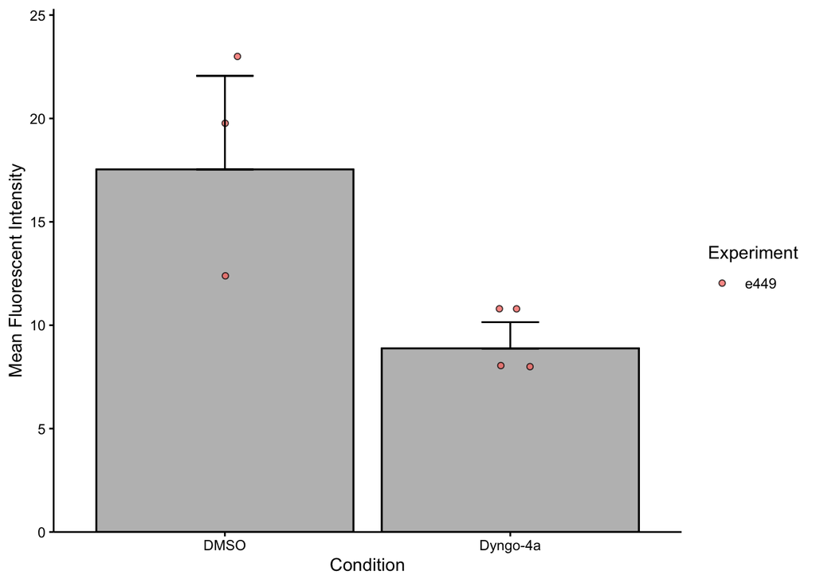

```r
# uptake_plot <- function(df, output_name) {
#   df_plot <- df %>%
#     group_by(tissue, condition, condition_avg, tissue_avg, condition_sd, exp) %>% #trimming the enormous data down to summary level for faster plotting
#     summarise() %>%
#     ggplot() +
#     geom_bar(aes(x = condition, y = condition_avg),color = "black", fill = "grey", position = "dodge", stat = "identity")+
#     geom_point(aes(x = condition, y = tissue_avg, fill = exp), shape =  21, alpha = 0.8, position = "jitter")+
#     geom_errorbar(aes(x = condition, ymin = condition_avg, ymax = condition_avg + condition_sd ), position = "dodge", width = 0.2)+
#     scale_y_continuous(expand = expansion(c(0,0.1)))+
#     theme_classic()+
#     theme(axis.text = element_text(color = "black"),
#           axis.ticks = element_line(color = "black"))
#
#   df_plot
#   ggsave(filename = paste0("output/", output_name, ".pdf"), device = "pdf", dpi = 300, height = 7, width = 5, scale = 0.8)
#   df_plot
# }

uptake_plot(all_dyngo_exps, output_name = "e1-449_pipeline-V4", condition_label = "Condition")
```